# Lab 6: Data Visualization

# One numeric and one categorical

How does the color of a diamond affect the carat?

### Stripchart

We return to the concept of dotplots, but now plot one for each category. These plots still only work well for small amounts of data, or if you’re plotting summary statitics like the mean. This looks like model notation, but notice that it plots the groups on the y axis and carat on the x.

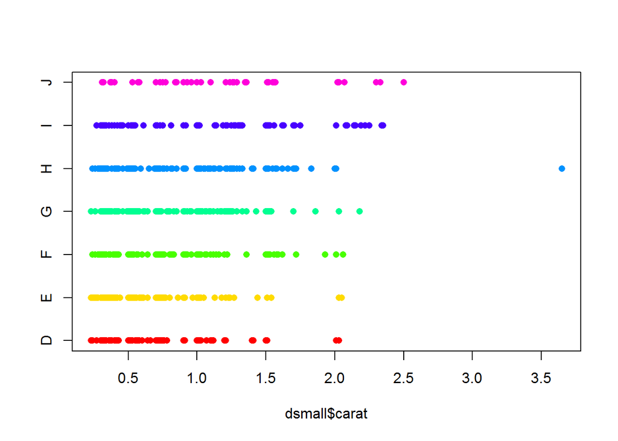

```r
stripchart(dsmall$carat ~ dsmall$color, pch=16, col=rainbow(7))
```

Note that the number that goes into the `rainbow()` argumnet is the number of categories that are to be colored. If you put a lower number here the colors will recycle. So you could end up with 2 red strips etc.

#### ggplot

Here is an example using `qplot` .

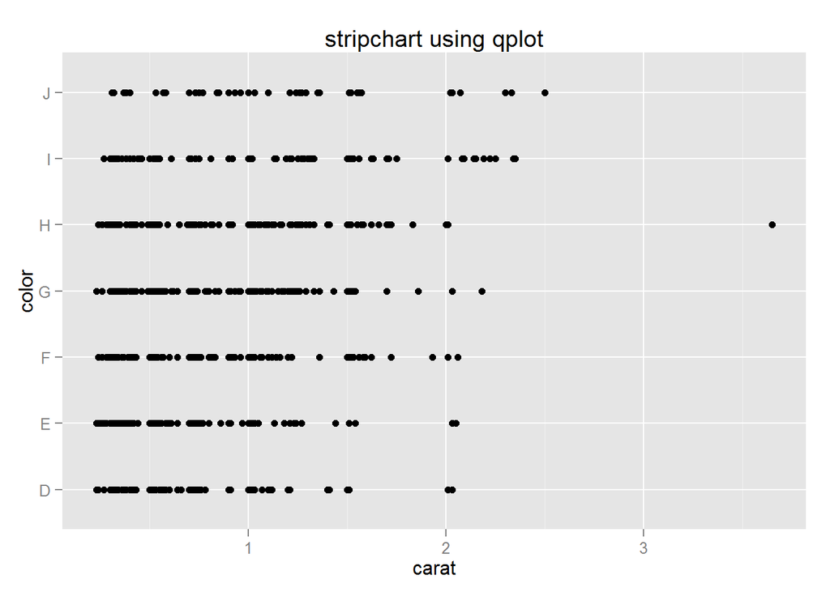

```r
qplot(x=carat, y=color, data=dsmall, geom="point", main="stripchart using qplot")
```

### Grouped boxplots

#### base graphics

Base graphics plots grouped boxplots with also just the addition of a twiddle `~`. Another example of where model notation works.

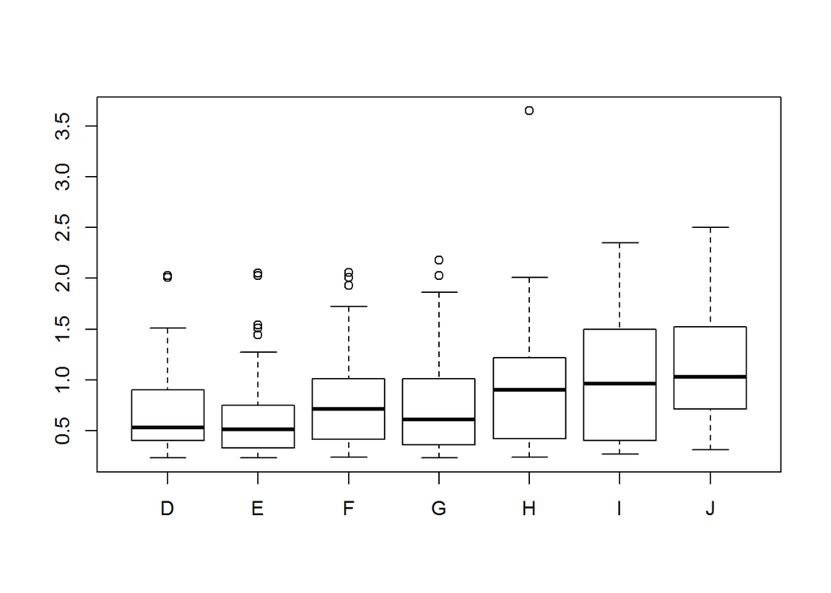

```r
boxplot(carat~color, data=dsmall)
```

#### ggplot

A simple addition, just define your x and y accordingly.

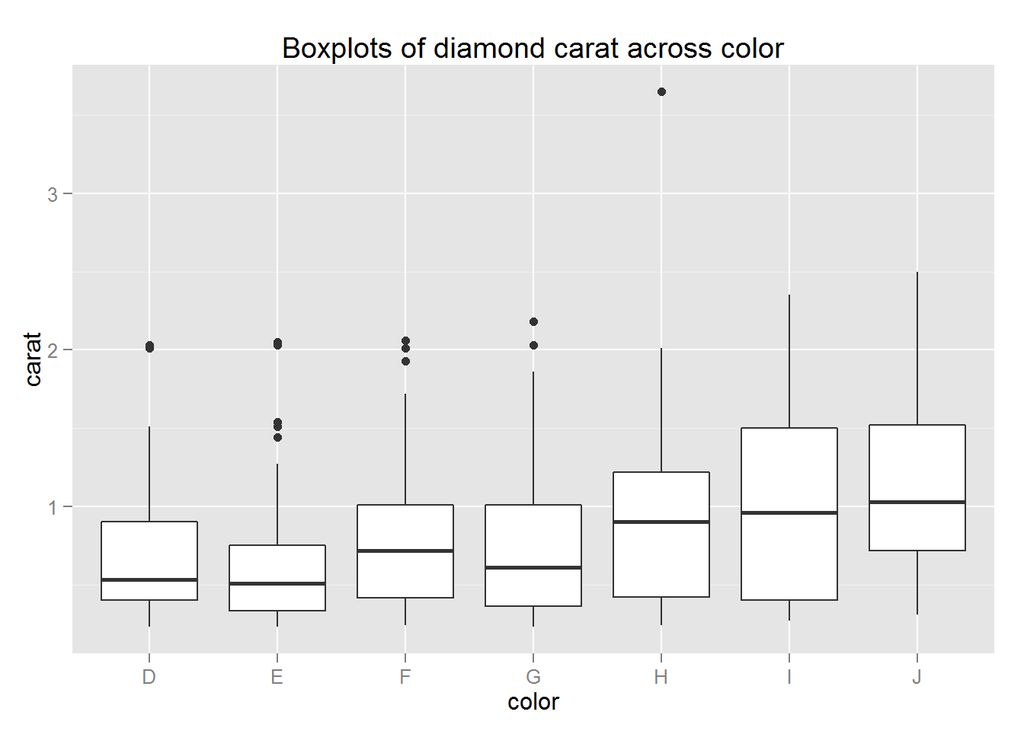

```r
qplot(x=color, y=carat, data=dsmall, geom="boxplot", main="Boxplots of diamond carat across color")
```

But what about the plotting colors man?

Add the variable you want to control the colors as an argument to color (for the outline) or fill.

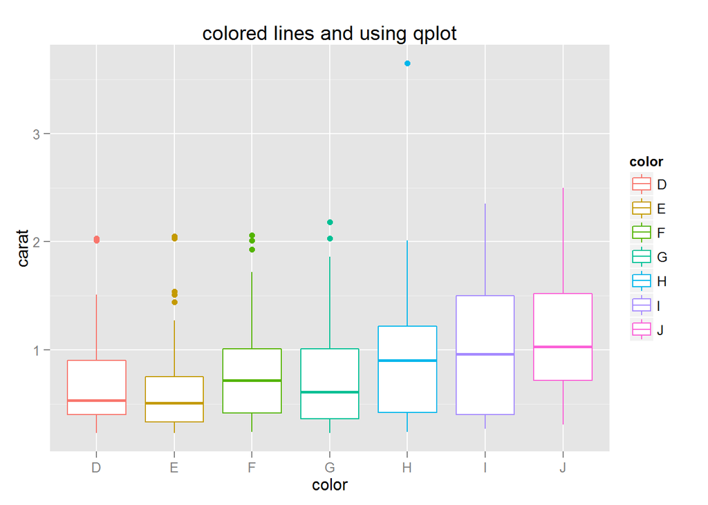

```r
qplot(x=color, y=carat, data=dsmall, geom="boxplot", color=color,
            main="colored lines and using qplot")
```

### Grouped histograms

#### base graphics

There is no easy way to create grouped histograms in base graphics we will skip it.

#### ggplot

By default ggplot wants to overlay all plots on the same grid. This doesn’t look to good with histograms. Instead you can overlay density plots

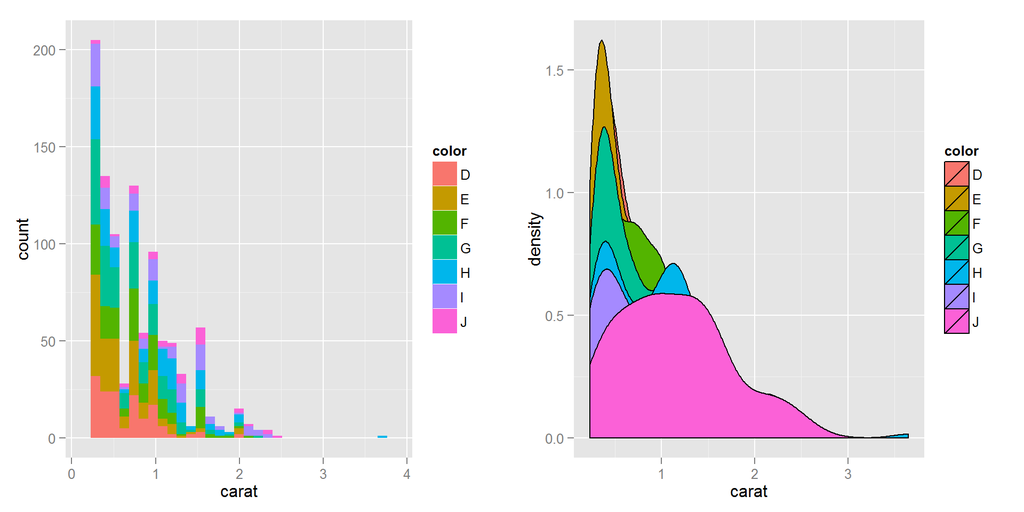

```r
a <- qplot(x=carat, data=dsmall, geom="histogram", fill=color)
b <- qplot(x=carat, data=dsmall, geom="density", fill=color)
grid.arrange(a,b, ncol=2)
```

The solid fills are still difficult to read, so we can either turn down the alpha (turn up the transparency) or only color the lines and not the fill.

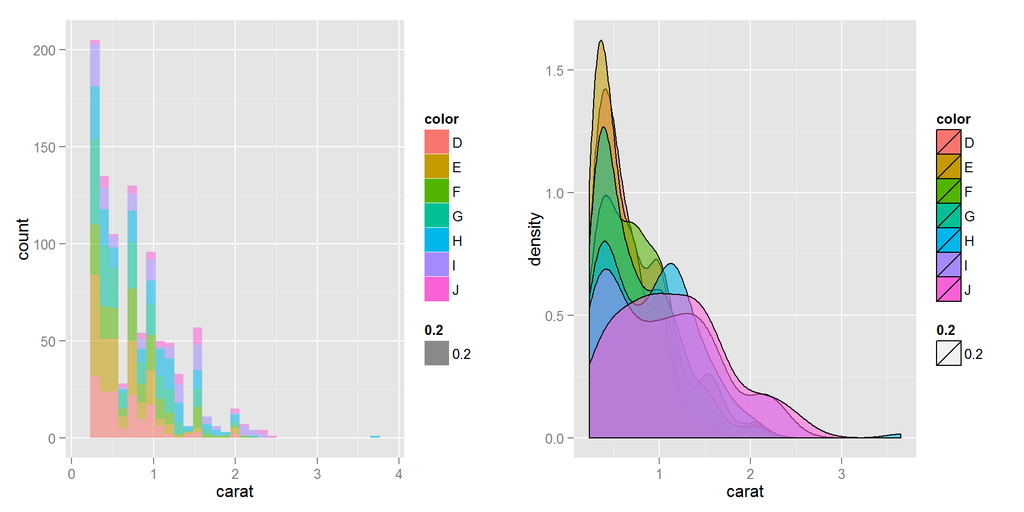

```r
a <- qplot(x=carat, data=dsmall, geom="histogram", fill=color, alpha=.2)
b <- qplot(x=carat, data=dsmall, geom="density", fill=color, alpha=.2)
grid.arrange(a,b, ncol=2)
```

But what if we **really** wanted to compare histograms?

# Faceting / paneling

ggplot introduces yet another term called `faceting`. The definition is *a particular aspect or feature of something*, or *one side of something many-sided, especially of a cut gem*. Basically instead of plotting the grouped graphics on the same plotting area, we let each group have it’s own plot, or facet.

Here are two examples of how `facets` can be used. Notice the position of the tilde in each

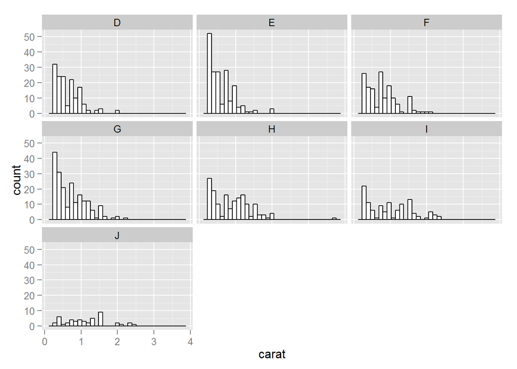

```r
qplot(x=carat, data=dsmall, geom="histogram", facets = ~color,
      color=I("black"), fill=I("white"))
```

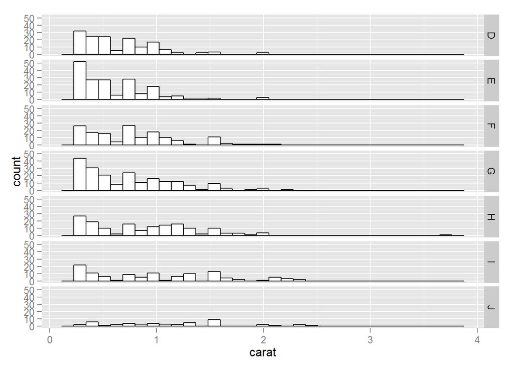

```r
qplot(x=carat, data=dsmall, geom="histogram", facets = color ~.,
      color=I("black"), fill=I("white"))
```

It is important when compmaring distributions across groups that they are on the same scale, and better yet on a single common axis. Our eyes can compare items vertically better than horizontally.

## Paneling on two variables

Who says we’re stuck with only faceting on one variable?

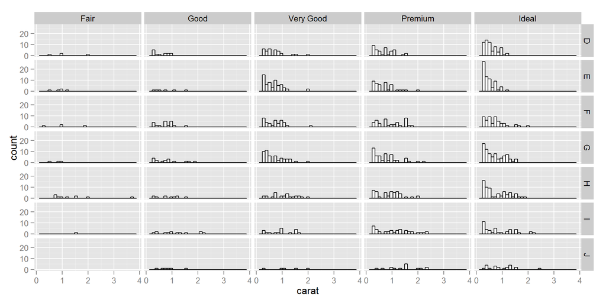

```r
qplot(x=carat, data=dsmall, geom="histogram", facets=color ~cut,
      color=I("black"), fill=I("white"))
```

And of course if we faceted on `cut~color` instead the rows and colums would simply switch.

How about plotting price against caret, for all combinations of color and clarity, with the points further separated by cut?

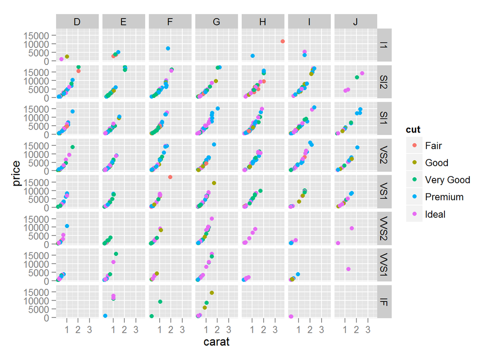

```r
qplot(x=carat, y=price, data=dsmall, geom="point", facets=clarity ~ color,
      color=cut)
```

Before you share your plot with any other eyes, always take a step back and try to expain what it is telling you. If you have to take more than a minute to get to the point then it may be too complex and simpler graphics are likely warranted.

# Additional Resources

- R Graphics Cookbook: http://www.cookbook-r.com/Graphs/ or http://amzn.com/1449316956 **Highly Highly Recommended**
- Quick-R: [Basic Graphs](http://www.statmethods.net/graphs/index.html)
- Quick-R: [ggplot2](http://www.statmethods.net/advgraphs/ggplot2.html)
- Books
  - ggplot2 http://ggplot2.org/book/ or http://amzn.com/0387981403
  - qplot http://ggplot2.org/book/qplot.pdf
- ggplot2 mailing list http://groups.google.com/group/ggplot2
- stackoverflow http://stackoverflow.com/tags/ggplot2